# RepData_PeerAssessment1

Victoria Mestre Runge

17 agost de 2020

### Required packages

```r
library("ggplot2")
library("dplyr")
library("lattice")
library("plyr")
```

### Loading and pre-processing the data

###### *Data examination can be made with summary(), str(), dim(), columns(), head(), tail(), dput() and View().*

```r
setwd("C:/Users/victo/Desktop/COURSERA/2020 Data Science Specialization/05. Reproducible Research/Course Project 1")
unzip("activity.zip")
# Loading data
originalDF <- read.csv("activity.csv", sep = ",", header=TRUE)
str(originalDF)
```

```
## 'data.frame':    17568 obs. of  3 variables:
##  $ steps   : int  NA NA NA NA NA NA NA NA NA NA ...
##  $ date    : Factor w/ 61 levels "2012-10-01","2012-10-02",..: 1 1 1 1 1 1 1 1 1 1 ...
##  $ interval: int  0 5 10 15 20 25 30 35 40 45 ...
```

```r
# Add hour and minute
originalDF <- mutate(originalDF, hour = interval %/% 100, minute = interval %% 100)
# Data set ignoring the missing values (NA)
tidy_originalDF <- na.omit(originalDF)
head(tidy_originalDF)
```

```
##     steps       date interval hour minute
## 289     0 2012-10-02        0    0      0
## 290     0 2012-10-02        5    0      5
## 291     0 2012-10-02       10    0     10
## 292     0 2012-10-02       15    0     15
## 293     0 2012-10-02       20    0     20
## 294     0 2012-10-02       25    0     25
```

### **1. What is mean total number of steps taken per day?**

#### **1.** Calculate total number of steps taken per day.

```r
# Group the number of steps by day
agg_ByDate <- aggregate(steps~date, tidy_originalDF, sum, na.rm=TRUE)
# Change variable names
names(agg_ByDate) <- c("date","total_steps")
# check if changes where made
head(agg_ByDate)
```

```
##         date total_steps
## 1 2012-10-02         126
## 2 2012-10-03       11352
## 3 2012-10-04       12116
## 4 2012-10-05       13294
## 5 2012-10-06       15420
## 6 2012-10-07       11015
```

#### **2.** Plot a histogram of the total number of steps taken each day.

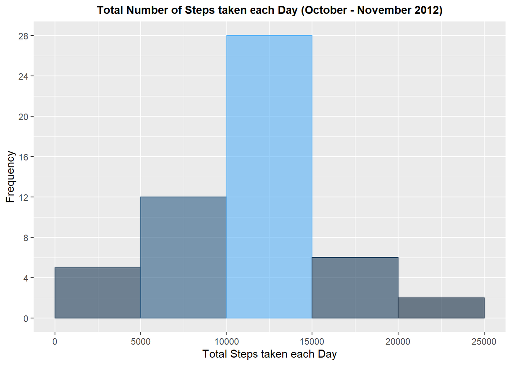

```r
ggplot(agg_ByDate, aes(total_steps, fill=..count.., col=..count..)) +
        geom_histogram(bins = 8, alpha = 0.6, position = "identity",
                       binwidth = 5000, boundary= 0) + # histogram with boundary (starting with 0)
        guides(fill=FALSE, col=FALSE) + # Remove legends of ..count..
        ggtitle("Total Number of Steps taken each Day (October - November 2012)") +
        theme(plot.title = element_text(face = "bold", size = 11, hjust = 0.5)) +
        xlab("Total Steps taken each Day") + ylab("Frequency") +
        scale_x_continuous(breaks=seq(from=0, to=25000, by=5000)) + # Adjusting the scale of the histogram
        scale_y_continuous(breaks=seq(from=0, to=28, by=4))
```

#### **3.** Calculate and report the mean and median of the total number of steps taken per day:

```r
summary(agg_ByDate$total_steps)
```

```
##    Min. 1st Qu.  Median    Mean 3rd Qu.    Max.
##      41    8841   10765   10766   13294   21194
```

###### *As we can see, the mean of steps taken per day is 10766, while the median is 10765.*

### **2. Which is the average daily activity pattern?**

#### **1.** Time series plot (i.e. type=“l”) of the 5-minute interval (x-axis) and the average number of steps taken, averaged across all day (y-axis).

```r
# Create a table with steps per time (from the data frame without NAs)
agg_ByTime <- aggregate(steps~interval, tidy_originalDF, mean, na.rm=TRUE)
# Change variable names
names(agg_ByTime) <- c("interval","mean_steps")
head(agg_ByTime)
```

```
##   interval mean_steps
## 1        0  1.7169811
## 2        5  0.3396226
## 3       10  0.1320755
## 4       15  0.1509434
## 5       20  0.0754717
## 6       25  2.0943396
```

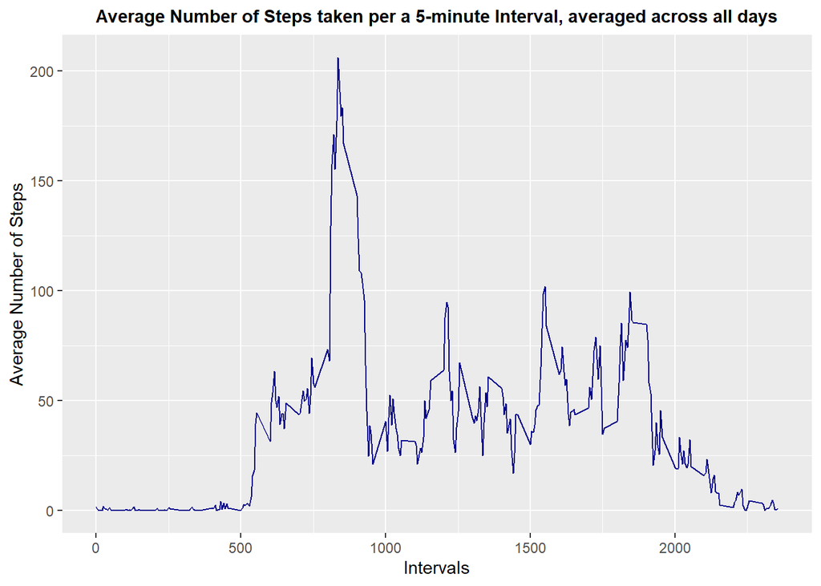

```r
# Plot the time series
ggplot(agg_ByTime, aes(interval, mean_steps)) +
        geom_line(col="darkblue") +
        ggtitle("Average Number of Steps taken per a 5-minute Interval, averaged across all days") +
        xlab("Intervals") + ylab("Average Number of Steps") +
        theme(plot.title = element_text(face="bold", size = 11, hjust = 0.5)) +
        scale_x_continuous(breaks=seq(from=0, to=2400, by=500)) + # Adjusting the scale
        scale_y_continuous(breaks=seq(from=0, to=250, by=50))
```

#### **2.** Which 5-minute interval, on average across all the days in the dataset, contains the maximum number of steps?

```r
# Interval that contains the maximum average number of steps
agg_ByTime[which.max(agg_ByTime$mean_steps), ]$interval
```

```
## [1] 835
```

```r
agg_ByTime[which.max(agg_ByTime$mean_steps), ]$mean_steps # additional information
```

```
## [1] 206.1698
```

```r
summary(agg_ByTime$mean_steps) # additional information
```

```
##    Min. 1st Qu.  Median    Mean 3rd Qu.    Max.
##   0.000   2.486  34.113  37.383  52.835 206.170
```

### **3. Imputing missing values**

#### **1.** Calculate and report the total number of missing values in the dataset

###### *To calculate the total number of NAs, the “originalDF” data frame has been used.*

```r
colSums(is.na(originalDF)) # Number of NAs in original data set
```

```
##    steps     date interval     hour   minute
##     2304        0        0        0        0
```

```r
mean(is.na(originalDF$steps)) # Proportion of the number of NAs
```

```
## [1] 0.1311475
```

###### *The strategy used to filling in all missing values in the new data set is the mean instead of the missing values*

#### **3.** Creating a new dataset that is equal to the original dataset but with the missing data filled in.

```r
# Create a new dataset equal to the "originalDF"
newDF <- originalDF
# Create a new column "imputed_steps" equal to the "steps" column
newDF$imputed_steps <- newDF$steps
# Fill the NAs values by using the mean
newDF$imputed_steps[is.na(newDF$steps)] <- mean(newDF$imputed_steps, na.rm = T)
# check if there are any missing values in the "imputed_steps"
colSums(is.na(newDF))
```

```
##         steps          date      interval          hour        minute
##          2304             0             0             0             0
## imputed_steps
##             0
```

```r
# check the newDF
str(newDF)
```

```
## 'data.frame':    17568 obs. of  6 variables:
##  $ steps        : int  NA NA NA NA NA NA NA NA NA NA ...
##  $ date         : Factor w/ 61 levels "2012-10-01","2012-10-02",..: 1 1 1 1 1 1 1 1 1 1 ...
##  $ interval     : int  0 5 10 15 20 25 30 35 40 45 ...
##  $ hour         : num  0 0 0 0 0 0 0 0 0 0 ...
##  $ minute       : num  0 5 10 15 20 25 30 35 40 45 ...
##  $ imputed_steps: num  37.4 37.4 37.4 37.4 37.4 ...
```

```r
head(newDF)
```

```
##   steps       date interval hour minute imputed_steps
## 1    NA 2012-10-01        0    0      0       37.3826
## 2    NA 2012-10-01        5    0      5       37.3826
## 3    NA 2012-10-01       10    0     10       37.3826
## 4    NA 2012-10-01       15    0     15       37.3826
## 5    NA 2012-10-01       20    0     20       37.3826
## 6    NA 2012-10-01       25    0     25       37.3826
```

#### **4.** Make a histogram of the total number of steps taken each day. Calculate and report the mean and median total number of steps taken per day. Do these values differ from the estimates from the first part of the assignment? What is the impact of imputing missing data on the estimates of the total daily number of steps?

```r
# Group the number of imputed_steps by day
agg_ByDate_imputed <- aggregate(imputed_steps~date, newDF, sum)
# Change variable names
names(agg_ByDate_imputed) <- c("date","total_imputed")
# check if changes where made
head(agg_ByDate_imputed)
```

```
##         date total_imputed
## 1 2012-10-01      10766.19
## 2 2012-10-02        126.00
## 3 2012-10-03      11352.00
## 4 2012-10-04      12116.00
## 5 2012-10-05      13294.00
## 6 2012-10-06      15420.00
```

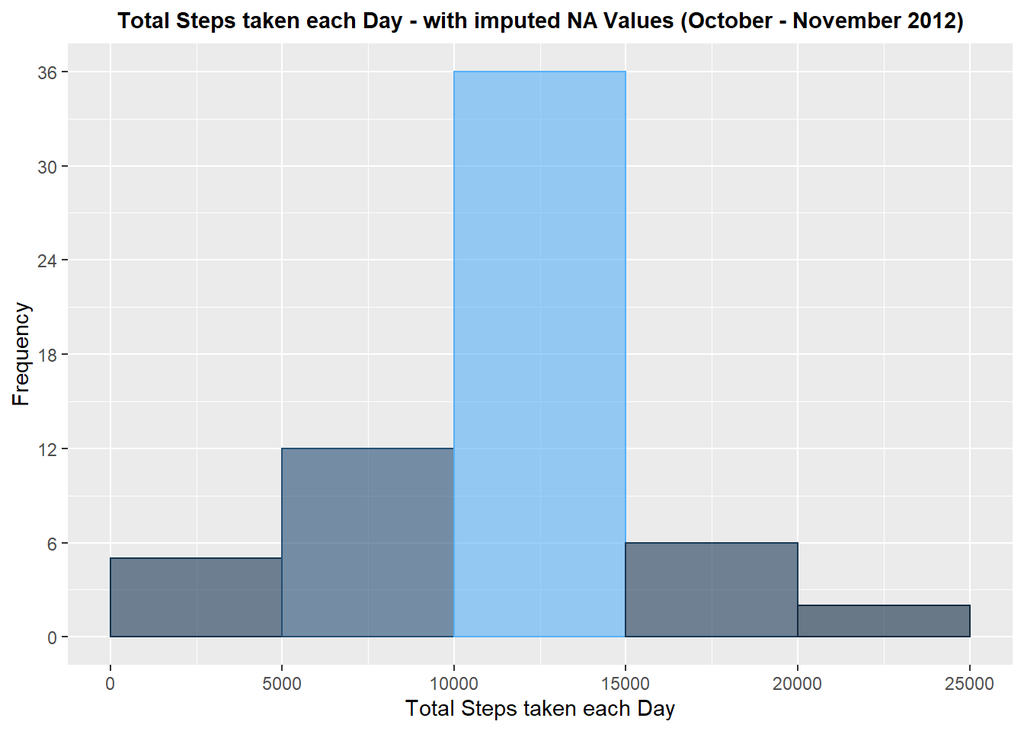

```r
# Plot the histogram
ggplot(agg_ByDate_imputed, aes(total_imputed, fill=..count.., col=..count..)) +
        geom_histogram(bins = 8, alpha = 0.6, position = "identity",
                       binwidth = 5000, boundary= 0) + # histogram with boundary (starting with 0)
        guides(fill=FALSE, col=FALSE) + # Remove legends of ..count..
        ggtitle("Total Steps taken each Day - with imputed NA Values (October - November 2012)") +
        theme(plot.title = element_text(face = "bold", size = 11, hjust = 0.5)) +
        xlab("Total Steps taken each Day") + ylab("Frequency") +
        scale_x_continuous(breaks=seq(from=0, to=25000, by=5000)) + # Adjusting the scale of the histogram
        scale_y_continuous(breaks=seq(from=0, to=40, by=6))
```

```r
summary(agg_ByDate_imputed$total_imputed)
```

```
##    Min. 1st Qu.  Median    Mean 3rd Qu.    Max.
##      41    9819   10766   10766   12811   21194
```

### **4. Are there differences in activity patterns between weekdays and weekends?**

#### **1.** Create a new factor variable in the dataset with two levels - “weekday” and “weekend” indicating whether a given date is a weekday or weekend day.

```r
# Create a new column with the name of the day
newDF$week_day <- weekdays(as.Date(newDF$date))
head(newDF)
```

```
##   steps       date interval hour minute imputed_steps week_day
## 1    NA 2012-10-01        0    0      0       37.3826  dilluns
## 2    NA 2012-10-01        5    0      5       37.3826  dilluns
## 3    NA 2012-10-01       10    0     10       37.3826  dilluns
## 4    NA 2012-10-01       15    0     15       37.3826  dilluns
## 5    NA 2012-10-01       20    0     20       37.3826  dilluns
## 6    NA 2012-10-01       25    0     25       37.3826  dilluns
```

```r
# Create a new column with the category name
newDF$day_category <- ifelse(newDF$week_day %in% c("dissabte", "diumenge"), "Weekend", "Weekday")
# convert column to factor
newDF$day_category <- factor(newDF$day_category)
head(newDF)
```

```
##   steps       date interval hour minute imputed_steps week_day day_category
## 1    NA 2012-10-01        0    0      0       37.3826  dilluns      Weekday
## 2    NA 2012-10-01        5    0      5       37.3826  dilluns      Weekday
## 3    NA 2012-10-01       10    0     10       37.3826  dilluns      Weekday
## 4    NA 2012-10-01       15    0     15       37.3826  dilluns      Weekday
## 5    NA 2012-10-01       20    0     20       37.3826  dilluns      Weekday
## 6    NA 2012-10-01       25    0     25       37.3826  dilluns      Weekday
```

```r
# Summarize data by "interval" and type of the "day_category"
agg_ByInterval <- ddply(newDF, ~interval+day_category, summarise, mean=mean(imputed_steps))
head(agg_ByInterval)
```

```
##   interval day_category     mean
## 1        0      Weekday 7.006569
## 2        0      Weekend 4.672825
## 3        5      Weekday 5.384347
## 4        5      Weekend 4.672825
## 5       10      Weekday 5.139902
## 6       10      Weekend 4.672825
```

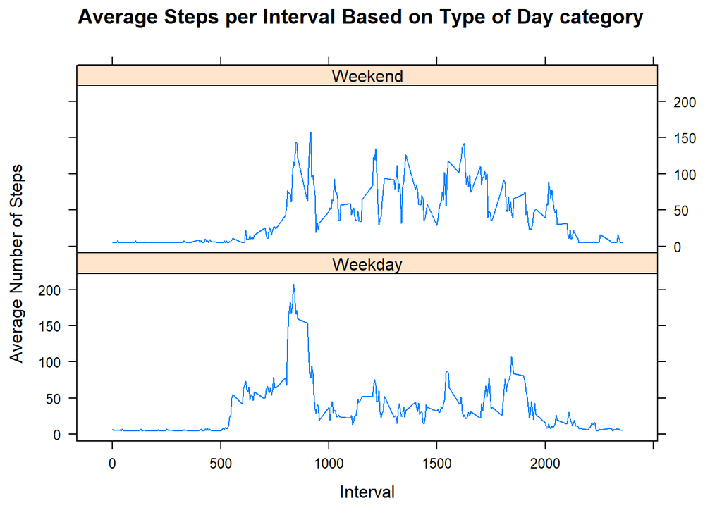

```r
# Plot data in a panel plot
xyplot(mean~interval|day_category, data = agg_ByInterval, type = "l", layout=c(1,2),
       main="Average Steps per Interval Based on Type of Day category",
       ylab="Average Number of Steps", xlab="Interval")
```